# DEQ R Workshop Activity:

Feburary 09, 2023

## Introduction

- Drafting a permit requires critical flows
- Here, we will calculate relevant stream flows for an imaginary facility on Caldwell’s Creek near Appomattox, Virginia.
- We will pull streamflow data from USGS gages using the **dataRetrieval** R package and run some basic **tidyverse** summary functions.
- Optionally, we can join site-specific data to our USGS gage data and scale our flow values to our permitting needs

## Step 1: Look at Site and Nearby Streamgages

- A [small facility](https://www.google.com/maps/place/37%C2%B019'40.9%22N+78%C2%B051'07.3%22W/@37.3238666,-78.8749752,13.21z/data=!4m5!3m4!1s0x0:0x995ab048038a848!8m2!3d37.328024!4d-78.85203) needs their VPDES permit renewed for their 2.5 MGD discharge to Caldwell’s Creek.
- Concerned with the discharge of Benzene to the creek. The human-health water quality criteria of 160 ug/L is applicable.
- We need to know what the *Harmonic Mean* flow of the stream is UPSTREAM of the facility for our RPA. So how can we calculate this?

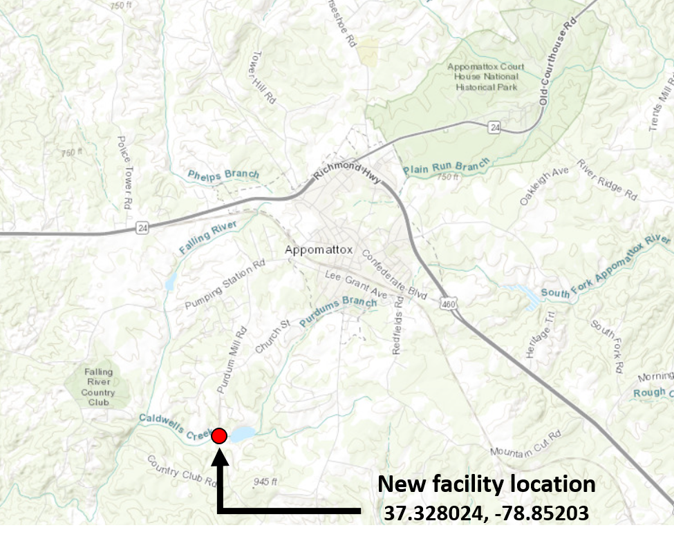

Our Facility on Caldwell’s Creek

## Step 1: Look for Nearby USGS Gages

We know there are two USGS gages downstream of our facility that have collected data for the past 80+ years. If we wanted to, we could search for additional nearby gages using the [DEQ DFLOW](https://rconnect.deq.virginia.gov/CombinedPWTool/) program.

| Gage ID | Gage Name | Start Date | End Date |
| --- | --- | --- | --- |
| **02062500** | **Roanoke River at Brookneal, VA** | **10/01/1923** | **Present** |
| 02064000 | Falling River Near Naruna, VA | 10/01/1929 | Present |

[interactive chart not shown]

## Step 2: Download and Investigate Gage Data

Now that we know what gage we want to look at, we need to pull in some data. We can use **dataRetrieval** to get all 100 years of data at once!

We will want to pull daily (USGS code “dv”) mean streamflow data (USGS parameter code “00060” and stat code “00003”). You can explore more [parameter](https://help.waterdata.usgs.gov/parameter_cd?group_cd=%) and [stat codes](https://help.waterdata.usgs.gov/code/stat_cd_nm_query?stat_nm_cd=%25&fmt=html) here.

## Step 2: Using Data Retrieval

```r
#Be sure to call the dataRetrieval library!
library(dataRetrieval)

#We will use the dataRetrieval function readNWISdv to get mean daily streamflow
gageData_all <- readNWISdv()

#Set the column names of the data frame to the following: "agency", "site_no",
#"Date", "Flow", "QC"
names(gageData_all) <-

#Let's see what we got
View(gageData_all)
```

## Step 2: Using Data Retrieval

```r
#Be sure to call the dataRetrieval library!
library(dataRetrieval)

#We will use the dataRetrieval function readNWISdv to get mean daily streamflow
gageData_all <- readNWISdv(siteNumbers = "02062500",parameterCd = "00060")

#Set the column names of the data frame to the following: "agency", "site_no",
#"Date", "Flow", "QC"
names(gageData_all) <- c("agency","site_no","Date","Flow","QC")

#Let's see what we got
# View(gageData_all)
```

## Step 2: Using Data Retrieval

You should get a data frame that has ~36,300 observations of 5 variables. That’s a lot of data!

| agency | site_no | Date | Flow | QC |
| --- | --- | --- | --- | --- |
| USGS | 02062500 | 1923-10-01 | 950 | A |
| USGS | 02062500 | 1923-10-02 | 950 | A |
| USGS | 02062500 | 1923-10-03 | 900 | A |
| USGS | 02062500 | 1923-10-04 | 900 | A |
| USGS | 02062500 | 1923-10-05 | 900 | A |
| USGS | 02062500 | 1923-10-06 | 900 | A |
| USGS | 02062500 | 1923-10-07 | 800 | A |
| USGS | 02062500 | 1923-10-08 | 850 | A |
| USGS | 02062500 | 1923-10-09 | 800 | A |
| USGS | 02062500 | 1923-10-10 | 800 | A |

[output cut: 90 more lines]

We will perform a very basic QC of the data. We want to make sure the mean annual flow of the River has not changed significantly.

## Step 2: Cleaning Up the Data

We need to clean up this data a bit. The USGS helps us out here by marking data as approved or provisional!

It’s easy for us to filter our with the last column of the data frame! We should remove all provisional data, labeled as “p”.

```r
#Be sure to call in the tidyverse pacakges!
library(tidyverse)

#Filter for instances where QC is not "P" (Provisional)
gageData_QC <- gageData_all %>%
```

## Step 2: Cleaning Up the Data

We need to clean up this data a bit. The USGS helps us out here by marking data as approved or provisional!

It’s easy for us to filter our with the last column of the data frame! We should remove all provisional data, labeled as “p”.

```r
#Be sure to call in the tidyverse pacakges!
library(tidyverse)

#Filter for instances where QC is not "P" (Provisional)
gageData_QC <- gageData_all %>%
  filter(QC != "P")

length(gageData_QC$Flow)
```

```
## [1] 36179
```

## Step 2: Working with Dates

Dates can sometimes be the hardest part of formatting. Dates are very easy for us to recognize, but can be tricky for computers.

We want to make new columns for gageData_QC that contain the year the streamflow was taken.

```r
#First, let's make sure R knows we are working with dates using as.Date on the
#Date column:
gageData_QC <- gageData_QC %>%

#Now, lets make good use of our dates. Lets get the year from the date column.
#We can use the year() function from lubridate!
library(lubridate)
gageData_QC <- gageData_QC %>%

#We should now see that we have data for 1923 - 2022:
unique(gageData_QC$Year)
```

## Step 2: Working with Dates

We want to make new columns for gageData_QC that contain the year the streamflow was taken.

```r
#First, let's make sure R knows we are working with dates using as.Date on the
#Date column:
gageData_QC <- gageData_QC %>% mutate(Date = as.Date(Date))

#Now, lets make good use of our dates. Lets get the year from the date column.
#We can use the year() function from lubridate!
library(lubridate)
gageData_QC <- gageData_QC %>% mutate(Year = year(Date))

#We should now see that we have data for 1923 - 2022:
head(unique(gageData_QC$Year))
```

```
## [1] 1923 1924 1925 1926 1927 1928
```

## Step 2: Visualizing our Data

| agency | site_no | Date | Flow | QC | Year |
| --- | --- | --- | --- | --- | --- |
| USGS | 02062500 | 1923-10-01 | 950 | A | 1923 |
| USGS | 02062500 | 1923-10-02 | 950 | A | 1923 |
| USGS | 02062500 | 1923-10-03 | 900 | A | 1923 |
| USGS | 02062500 | 1923-10-04 | 900 | A | 1923 |
| USGS | 02062500 | 1923-10-05 | 900 | A | 1923 |
| USGS | 02062500 | 1923-10-06 | 900 | A | 1923 |
| USGS | 02062500 | 1923-10-07 | 800 | A | 1923 |
| USGS | 02062500 | 1923-10-08 | 850 | A | 1923 |
| USGS | 02062500 | 1923-10-09 | 800 | A | 1923 |
| USGS | 02062500 | 1923-10-10 | 800 | A | 1923 |

[output cut: 90 more lines]

## Step 2: Visualizing our Data

Create a data frame that contains the mean flow and minimum daily flow for each year on record.

**Hint:** Remember that *summarize()* always needs *group_by()*

```r
#Remember, group_by and summarize always go together!
gageData_summary <- gageData_QC %>%
```

## Step 2: Visualizing our Data

Create a data frame that contains the mean flow and minimum daily flow for each year on record.

**Hint:** Remember that *summarize()* always needs *group_by()*

```r
#Remember, group_by and summarize
#always go together!
gageData_summary <- gageData_QC %>%
  group_by(Year) %>%
    summarize(MeanFlow = mean(Flow),
              MinFlow = min(Flow))
```

| Year | MeanFlow | MinFlow |
| --- | --- | --- |
| 1923 | 1207.39130434783 | 750 |
| 1924 | 2765.87431693989 | 850 |
| 1925 | 1887.6301369863 | 460 |
| 1926 | 1748.19178082192 | 370 |
| 1927 | 2269.78082191781 | 500 |
| 1928 | 3019.83606557377 | 575 |
| 1929 | 3068.09315068493 | 782 |
| 1930 | 1329.77260273973 | 274 |
| 1931 | 1394.34520547945 | 420 |
| 1932 | 2136.11202185792 | 191 |

[output cut: 90 more lines]

## Step 2: Visualizing our Data

Plot BOTH minimum and mean flow with year on the x-axis and flow on the y-axis!

```r
#Plot the data
ggplot(gageData_summary) +
  geom_point(col="blue") +
  geom_point(col="red") +
  theme_classic()
```

## Step 2: Visualizing our Data

Plot BOTH minimum and mean flow with year on the x-axis and flow on the y-axis!

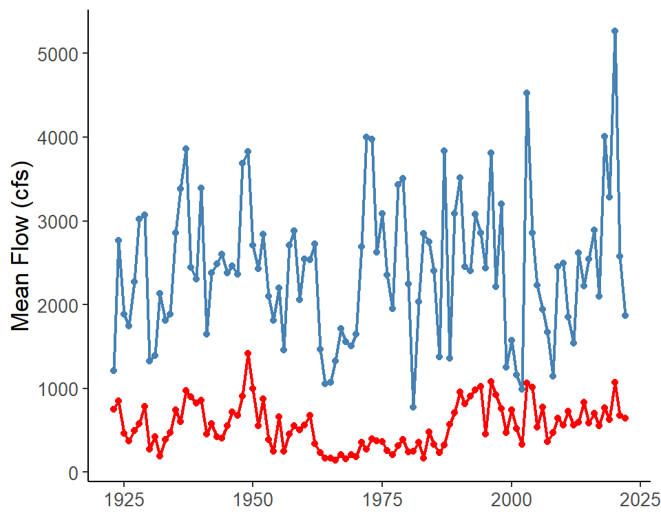

```r
#Plot the data
ggplot(gageData_summary) +
  geom_line(aes(x = Year,y = MeanFlow),
            col = "blue") +
  geom_point(aes(x = Year,y = MeanFlow),
             col = "blue") +
  geom_line(aes(x = Year,y = MinFlow),
            col = "red") +
  geom_point(aes(x = Year,y = MinFlow),
             col = "red") +
  theme_classic()
```

## Step 2: Visualizing our Data

What is happening around 1963? Why is there a change in flow variability?

[interactive chart not shown]

## Step 2: The Decision

Instead, we will use gage 02064000 which has a more stable flow record (notice that we must filter for “P Ice” as well)

```r
#We will use the dataRetrieval function readNWISdv to get mean daily streamflow
gageData_all <- readNWISdv("02064000",parameterCd = "00060")
#We will set some names for the data frame to make it easier to work with
names(gageData_all) <- c("agency","site_no","Date","Flow","QC")
#Filter for instances where QC is not "P" (Provisional)
gageData_QC <- gageData_all %>%
  filter(QC != "P", QC != "P Ice")
```

## Step 3: Calculate the Harmonic Mean

To adjust for any days of zero flow, we can do the following calculation:  
\[HM_u=\Sigma \frac{1}{Q}\] \[HM=\frac{(N_d-n_z)}{HM_u} * \frac{N_d-n_z}{N_d}\] Where \(N_d\) is the total number of days and \(n_z\) is the number of days of zero flow.

## Step 3: Calculate the Harmonic Mean

So, let’s start off by first creating a data frame that has all the non-zero flow values and then calculating \(N_d\) and \(n_z\) (perhaps using the length() or dim() functions)

```r
#Let's filter our gageData_QC to only include positive flow values
gageData_noZeros <- gageData_QC %>%


#We can use length to determine how many flow entries there are in our complete dataset
N_d <- length()
#We can then calculate the difference between N_d and gageData_noZeroes
n_z <-
```

## Step 3: Calculate the Harmonic Mean

So, let’s start off by first creating a data frame that has all the non-zero flow values and then calculating \(N_d\) and \(n_z\) (perhaps using the length() or dim() functions)

```r
#Let's filter our gageData_QC to only include positive flow values
gageData_noZeros <- gageData_QC %>%
  filter(!is.na(Flow)) %>%
  filter(Flow > 0)
#We can use length to determine how many flow entries there are in our complete dataset
N_d <- length(gageData_QC$Flow)
#We can then calculate the difference between N_d and gageData_noZeroes
n_z <- N_d - length(gageData_noZeros$Flow)

N_d;n_z
```

```
## [1] 31131
```

```
## [1] 0
```

## Step 3: Calculate the Harmonic Mean

You should see that at this gage, all flow values are above zero! This makes the harmonic mean calculation easy!

```r
#Let's calculate the harmonic mean flow using the formula above:
HM_u <-
HM <-
```

## Step 3: Calculate the Harmonic Mean

You should see that at this gage, all flow values are above zero! This makes the harmonic mean calculation easy!

```r
#Let's calculate the harmonic mean flow using the formula above:
HM_u <- sum(1 / gageData_noZeros$Flow)
HM <- ((N_d-n_z)/HM_u) * ((N_d-n_z) / N_d)
HM
```

```
## [1] 67.29827
```

The harmonic mean flow is about 67.3 cfs at this gage!

## Questions?

## Step 4: Scaling the Stream Flows

- We calculated the harmonic mean at the USGS gage on Falling River, but our site is nearly 15 miles upstream!
- We can scale the flow using streamflow data collected at our facility, on-and-off, for the past 20 years
- A regression of the USGS gage streamflow and upstream flow at our facility will be the key to getting our permitted flow values

## Step 4: Reading in the Data

First, let’s read in the streamflow and discharge data provided by the facility. The data are both provided in csv files.

```r
#We need to read in the csv files for both the stream flow and the discharge (dis) data
facilityFlow <- read_csv("data/facilityFlowinMGD.csv")
facilityDis <- read_csv("data/facilityDischargeinMGD.csv")
```

## Step 4: Reading in the Data

Notice that the discharge information has been provided in a wide format. We will need to adjust this to a long format.

| measType | 07-Mar-00 | 01-May-00 | 08-May-00 | 18-Jun-00 | 22-Jul-00 | 06-Aug-01 | 27-Sep-01 | 06-Dec-01 | 23-Dec-01 | 11-Jan-02 | 19-Jan-02 | 16-Mar-02 | 29-Oct-02 | 07-Mar-03 | 10-Mar-03 | 04-Apr-03 | 11-Nov-03 | 21-Dec-03 | 17-Aug-04 | 08-Sep-04 | 13-Sep-04 | 19-Nov-04 | 24-Feb-05 | 08-May-05 | 10-Sep-05 | 01-Feb-06 | 09-Feb-06 | 20-Mar-06 | 11-Jun-06 | … |
| --- | --- | --- | --- | --- | --- | --- | --- | --- | --- | --- | --- | --- | --- | --- | --- | --- | --- | --- | --- | --- | --- | --- | --- | --- | --- | --- | --- | --- | --- | --- |
| Flow | 1.2 | 1.5 | 0.95 | 1.3 | 0.74 | 0.72 | 0.81 | 0.89 | 0.97 | 0.86 | 0.79 | 1.3 | 0.73 | 1.1 | 0.81 | 1.1 | 1.1 | 1 | 1.1 | 1.1 | 1.1 | 1.3 | 0.86 | 0.96 | 1.1 | 1.4 | 1.9 | 1.1 | 0.85 | … |
| Hardness | 86 | 80 | 60 | 45 | 60 | 86 | 102 | 68 | 76 | 97 | 88 | 91 | 92 | 64 | 57 | 78 | 115 | 86 | 64 | 61 | 99 | 99 | 80 | 63 | 98 | 97 | 38 | 73 | 50 | … |
| pH | 7.17 | 6.88 | 7.13 | 6.82 | 6.8 | 7.16 | 6.77 | 6.93 | 6.95 | 6.94 | 6.82 | 7.17 | 7.19 | 7.26 | 7.03 | 7.01 | 7.1 | 7.28 | 7.13 | 6.85 | 7.3 | 6.73 | 6.65 | 6.88 | 7.21 | 6.38 | 7.07 | 6.77 | 7.13 | … |

## Step 4A: Transforming the Data

We can filter for just the streamflow (we don’t need the pH or hardness data). It would be helpful to make sure flow values are in a column labeled “FlowMGD”, perhaps using select().

```r
# We can use tidyverse functions to pivot the table into a long-form dataset, then
#filter to only have flow values. Finally, we can use select to rename and
#select columns:
facilityDis_long <- facilityDis %>%
```

## Step 4A: Transforming the Data

We can filter for just the streamflow (we don’t need the pH or hardness data). It would be helpful to make sure flow values are in a column labeled “FlowMGD”, perhaps using select().

```r
#We can use tidyverse functions to
#pivot the table into a long-form
#dataset, then filter to only have
#flow values. Finally, we can use
#select to refine and rename columns:
facilityDis_long <- facilityDis %>%
  pivot_longer(cols = -measType,
               names_to = "Date")
```

| measType | Date | value |
| --- | --- | --- |
| Flow | 07-Mar-00 | 1.2 |
| Flow | 01-May-00 | 1.5 |
| Flow | 08-May-00 | 0.95 |
| Flow | 18-Jun-00 | 1.3 |
| Flow | 22-Jul-00 | 0.74 |
| Flow | 06-Aug-01 | 0.72 |
| Flow | 27-Sep-01 | 0.81 |
| Flow | 06-Dec-01 | 0.89 |
| Flow | 23-Dec-01 | 0.97 |
| Flow | 11-Jan-02 | 0.86 |

[output cut: 281 more lines]

## Step 4A: Transform and Filter the Data

We can filter for just the streamflow (we don’t need the pH or hardness data). It would be helpful to make sure flow values are in a column labeled “FlowMGD”, perhaps using select().

```r
#We can use tidyverse functions to
#pivot the table into a long-form
#dataset, then filter to only have
#flow values. Finally, we can use
#select to refine and rename columns:
facilityDis_long <- facilityDis_long %>%
  filter(measType == "Flow") %>%
  select(Date,FlowMGD = value)
```

| Date | Flow (MGD) |
| --- | --- |
| 07-Mar-00 | 1.2 |
| 01-May-00 | 1.5 |
| 08-May-00 | 0.95 |
| 18-Jun-00 | 1.3 |
| 22-Jul-00 | 0.74 |
| 06-Aug-01 | 0.72 |
| 27-Sep-01 | 0.81 |
| 06-Dec-01 | 0.89 |
| 23-Dec-01 | 0.97 |
| 11-Jan-02 | 0.86 |

[output cut: 87 more lines]

## Step 4A: Fixing the Dates

The operator entered the dates using abbreviations. How can we fix this?

as.Date()! Check out the format section under the help menu. You will need to enter a custom format using strptime. See the help menu for strptime or this [link](https://www.stat.berkeley.edu/~s133/dates.html). There are a few hints below if you find yourself stuck. Dates are tricky!

```r
#We need to make sure R knows there are dates here
facilityFlow$Date <- as.Date(facilityFlow$Date)
#For the discharge data, the dates are in the format 01-Jan-21 to represent
#January 1, 2021. We need to make sure R looks for this custom format using
#the strptime helpers
facilityDis_long$Date <-
```

## Step 4A: Fixing the Dates

*Hint 1:* The standard R date format is %Y-%m-%d, representing a date in the format YYYY-mm-dd. We can use %d to represent the day, but we need to find the code for the abbreviated month and the two-digit year.

*Hint 2:* You will need %d to represent the days, %b to represent the abbreviated month, and %y to represent the two-digit year

```r
#We need to make sure R knows there are dates here
facilityFlow$Date <- as.Date(facilityFlow$Date)
#For the discharge data, the dates are in the format 01-Jan-21 to represent
#January 1, 2021. We need to make sure R looks for this custom format
facilityDis_long$Date <- as.Date(facilityDis_long$Date,format = "%d-%b-%y")

facilityDis_long$Date[1];class(facilityDis_long$Date)
```

```
## [1] "2000-03-07"
```

```
## [1] "Date"
```

## Step 4B: Determine Upstream Flow

We have the flow downstream of our facility and the discharge from the facility, but we need the flow upstream of the discharge (so the streamflow that excludes the discharge flow!).

We will need to convert that flow into CFS (1 MGD = 1.547229 CFS)!

```r
#Lets create a data frame to store our flow upstream of our facility. It will
#have all of the dates in facilityFlow
upstreamFlow <- facilityFlow
#Subtract the discharge from the facility from the flow downstream of our facility
upstreamFlow$FlowMGD <-
#Convert to cfs!
upstreamFlow <-
```

In general, you should only compare low flow data. However, in this example, we use a bigger dataset for the purposes of illustration.

## Step 4B: Determine Upstream Flow

We have the flow downstream of our facility and the discharge from the facility, but we need the flow upstream of the discharge (so the streamflow that excludes the discharge flow!).

We will need to convert that flow into CFS (1 MGD = 1.547229 CFS)!

```r
#Lets create a data frame to store our flow upstream of our facility. It will
#have all of the dates in facilityFlow
upstreamFlow <- facilityFlow
#Subtract the discharge from the facility from the flow downstream of our facility
upstreamFlow$FlowMGD <- upstreamFlow$FlowMGD - facilityDis_long$FlowMGD
#Convert to cfs!
upstreamFlow <- upstreamFlow %>%
  mutate(FlowCFS = FlowMGD * 1000000 * 231 / 12 / 12 / 12 / 3600 / 24)
```

## Step 4B: Determine Upstream Flow

| Date | Upstream Flow (MGD) | Upstream Flow (CFS) |
| --- | --- | --- |
| 2000-03-07 | 3.11 | 4.81188110853909 |
| 2000-05-01 | 66.09 | 102.256341628086 |
| 2000-05-08 | 4.41 | 6.82327835648148 |
| 2000-06-18 | 1.31 | 2.02686953446502 |
| 2000-07-22 | 22.27 | 34.4567820859054 |
| 2001-08-06 | 4.97 | 7.68972640174897 |
| 2001-09-27 | 0.6 | 0.928337191358025 |
| 2001-12-06 | 2 | 3.09445730452675 |
| 2001-12-23 | 2.34 | 3.6205150462963 |
| 2002-01-11 | 0.2 | 0.309445730452675 |

[output cut: 87 more lines]

## Step 4B: Join and Compare Flows

To adjust the harmonic mean, we can compare the flow upstream of our facility to the flow at the USGS gage.

To start, we need to get all of our data in one place using some kind of join()

Rename the upstream flow (in cfs) to be “UpstreamFlow” and the gage flow to be “GageFlow”

```r
#We will need to join in gageData_QC. We only want to keep dates that are in
#both the gage data and our facility data. Plus we will want to rename the
#columns to something more meaningful
flowComparison <- upstreamFlow %>%
```

## Step 4B: Join and Compare Flows

Using *inner_join()*, we can create a data frame that has all of the flow values that occurred on dates that are present in **both** *upstreamFlow* and *gageData_QC*

```r
#We will need to join in gageData_QC.
#We only want to keep dates that are in
#both the gage data and our facility
#data. Plus we will want to rename the
#columns to something more meaningful
flowComparison <- upstreamFlow %>%
  inner_join(gageData_QC,
             by = "Date") %>%
  select(Date,
         UpstreamFlow = FlowCFS,
         GageFlow = Flow)
```

| Date | U/S Q (CFS) | Gage Q (CFS) |
| --- | --- | --- |
| 2000-03-07 | 4.81188110853909 | 74 |
| 2000-05-01 | 102.256341628086 | 125 |
| 2000-05-08 | 6.82327835648148 | 79 |
| 2000-06-18 | 2.02686953446502 | 68 |
| 2000-07-22 | 34.4567820859054 | 42 |
| 2001-08-06 | 7.68972640174897 | 26 |
| 2001-09-27 | 0.928337191358025 | 19 |
| 2001-12-06 | 3.09445730452675 | 27.9 |
| 2001-12-23 | 3.6205150462963 | 36.2 |
| 2002-01-11 | 0.309445730452675 | 47.8 |

[output cut: 87 more lines]

## Step 4B: Join and Compare Flows

Plot UpstreamFlow on the y-axis and GageFlow on the x-axis

```r
#Plot the data
p <- ggplot(data = flowComparison) +
  geom_point(aes()) +
  xlab("Falling River Gage (cfs)") + ylab("Caldwell's Creek (cfs)") +
  theme_classic() +
  theme(panel.grid.major = element_line(color = "grey",linetype = 3))

p
```

## Step 4B: Join and Compare Flows

Plot UpstreamFlow on the y-axis and GageFlow on the x-axis

```r
#Plot the data
p <- ggplot(data = flowComparison) +
  geom_point(aes(x = GageFlow,
                 y = UpstreamFlow)) +
  xlab("Falling River Gage (cfs)") +
  ylab("Caldwell's Creek (cfs)") +
  theme_classic() +
  theme(panel.grid.major =
          element_line(color = "grey",
                       linetype = 3))

p
```

[interactive chart not shown]

## Step 4B: Conduct a NLS Regression

```r
#We can use nls to determine a relationship between GageFlow and UpstreamFlow
#by providing it a formula and initial guesses
NLR <- nls(data = flowComparison,
           formula = UpstreamFlow ~ A * GageFlow ^ B,
           start = c(A = 1,B = 1))
#Using summary(), we can learn more about our regression
summary(NLR)
```

```
##
## Formula: UpstreamFlow ~ A * GageFlow^B
##
## Parameters:
##   Estimate Std. Error t value Pr(>|t|)
## A  0.49417    0.26190   1.887   0.0622 .
## B  0.92482    0.09684   9.550 1.52e-15 ***
## ---
## Signif. codes:  0 '***' 0.001 '**' 0.01 '*' 0.05 '.' 0.1 ' ' 1
##
## Residual standard error: 31.1 on 95 degrees of freedom
##
## Number of iterations to convergence: 5
## Achieved convergence tolerance: 1.217e-06
```

## Step 4B: Create a Flow Prediction Function

We can turn our NLS object into a function to predict flow! Again, this is pretty advanced but it shows how easy custom functions are to work with!

```r
#We create a function out of our regression called regFun to estimate flow at our
#site based on a USGS flow
regFun <- function(GageFlow,NLR){
  coeffA <- coef(NLR)[[1]]
  coeffB <- coef(NLR)[[2]]

  Qupstream <- coeffA * GageFlow ^ coeffB
  return(Qupstream)
}

#Test regFun for yourself:
regFun(300,NLR)
```

```
## [1] 96.55429
```

## Step 4B: Calculate the Final Harmonic Mean

We built a custom function, regFun, that uses a non-linear regression to predict flow upstream of our facility.

Let’s include it on our plot and finally use it to calculate the Harmonic Mean upstream of our facility.

```r
p + stat_function(fun = ,
                  args = list(NLR=NLR),
                  col="navy")

#So, the harmonic mean upstream our facility is:
regFun()
```

## Step 4B: Calculate the Final Harmonic Mean

```r
p + stat_function(fun = regFun,
                  args = list(NLR=NLR),
                  col = "navy")

#So, the harmonic mean upstream
#our facility is:
regFun(HM,NLR)
```

[output not shown]

Our harmonic mean is about 24.3 cfs!

[figure not shown]

## Questions?

Email Connor Brogan if you have any trouble with the bonus exercises!